# Week 6 - Lectures & Quick Questions

Vishal Gupta

3/30/2019

```r
library(dplyr)
library(rpart)
library(rpart.plot)
library(caTools)
library(ROCR)
library(randomForest)
```

## Recommendations Worth a Million: An Introduction to Clustering

#### Video 6: Getting the Data

Loading the data

```r
movies = read.table("~/Downloads/movieLens.txt", header=FALSE, sep="|",quote="\"")
```

Adding column names

```r
colnames(movies) = c("ID", "Title", "ReleaseDate", "VideoReleaseDate", "IMDB", "Unknown", "Action", "Adventure", "Animation", "Childrens", "Comedy", "Crime", "Documentary", "Drama", "Fantasy", "FilmNoir", "Horror", "Musical", "Mystery", "Romance", "SciFi", "Thriller", "War", "Western")
str(movies)
```

```
## 'data.frame':    1682 obs. of  24 variables:
##  $ ID              : int  1 2 3 4 5 6 7 8 9 10 ...
##  $ Title           : Factor w/ 1664 levels "'Til There Was You (1997)",..: 1525 618 555 594 344 1318 1545 111 391 1240 ...
##  $ ReleaseDate     : Factor w/ 241 levels "","01-Aug-1997",..: 71 71 71 71 71 71 71 71 71 182 ...
##  $ VideoReleaseDate: logi  NA NA NA NA NA NA ...
##  $ IMDB            : Factor w/ 1661 levels "","http://us.imdb.com/M/title-exact?%22Langoliers,%20The%22%20(1995)%20(mini)",..: 1430 564 504 542 309 1661 1452 102 356 1182 ...
##  $ Unknown         : int  0 0 0 0 0 0 0 0 0 0 ...
##  $ Action          : int  0 1 0 1 0 0 0 0 0 0 ...
##  $ Adventure       : int  0 1 0 0 0 0 0 0 0 0 ...
##  $ Animation       : int  1 0 0 0 0 0 0 0 0 0 ...
##  $ Childrens       : int  1 0 0 0 0 0 0 1 0 0 ...
##  $ Comedy          : int  1 0 0 1 0 0 0 1 0 0 ...
##  $ Crime           : int  0 0 0 0 1 0 0 0 0 0 ...
##  $ Documentary     : int  0 0 0 0 0 0 0 0 0 0 ...
##  $ Drama           : int  0 0 0 1 1 1 1 1 1 1 ...
##  $ Fantasy         : int  0 0 0 0 0 0 0 0 0 0 ...
##  $ FilmNoir        : int  0 0 0 0 0 0 0 0 0 0 ...
##  $ Horror          : int  0 0 0 0 0 0 0 0 0 0 ...
##  $ Musical         : int  0 0 0 0 0 0 0 0 0 0 ...
##  $ Mystery         : int  0 0 0 0 0 0 0 0 0 0 ...
##  $ Romance         : int  0 0 0 0 0 0 0 0 0 0 ...
##  $ SciFi           : int  0 0 0 0 0 0 1 0 0 0 ...
##  $ Thriller        : int  0 1 1 0 1 0 0 0 0 0 ...
##  $ War             : int  0 0 0 0 0 0 0 0 0 1 ...
##  $ Western         : int  0 0 0 0 0 0 0 0 0 0 ...
```

Remove unnecessary variables

```r
movies$ID = NULL
movies$ReleaseDate = NULL
movies$VideoReleaseDate = NULL
movies$IMDB = NULL
```

Remove duplicates

```r
movies = unique(movies)
```

#### Quick Question

Using the table function in R, please answer the following questions about the dataset “movies”.

How many movies are classified as comedies?

```r
table(movies$Comedy)
```

```
##
##    0    1
## 1162  502
```

How many movies are classified as westerns?

```r
table(movies$Western)
```

```
##
##    0    1
## 1637   27
```

How many movies are classified as romance AND drama?

```r
table(movies$Romance & movies$Drama)
```

```
##
## FALSE  TRUE
##  1567    97
```

#### Video 7: Hierarchical Clustering in R

Compute distances

```r
distances = dist(movies[2:20], method = "euclidean")
```

Hierarchical clustering

```r
clusterMovies = hclust(distances, method = "ward")
```

```
## The "ward" method has been renamed to "ward.D"; note new "ward.D2"
```

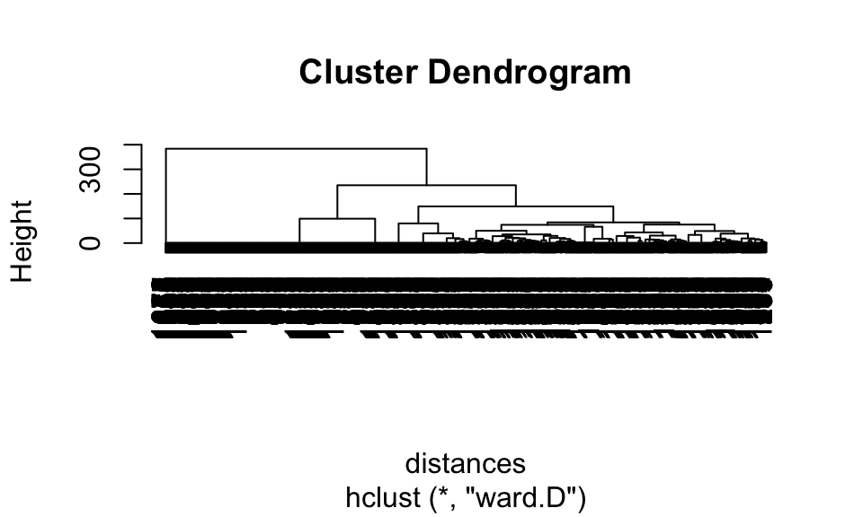

```r
plot(clusterMovies)
```

Assign points to clusters

```r
clusterGroups = cutree(clusterMovies, k = 10)
```

Computing the percentage of movies in each genre and cluster

```r
tapply(movies$Action, clusterGroups, mean)
```

```
##         1         2         3         4         5         6         7
## 0.1784512 0.7839196 0.1238532 0.0000000 0.0000000 0.1015625 0.0000000
##         8         9        10
## 0.0000000 0.0000000 0.0000000
```

```r
tapply(movies$Romance, clusterGroups, mean)
```

```
##          1          2          3          4          5          6
## 0.10437710 0.04522613 0.03669725 0.00000000 0.00000000 1.00000000
##          7          8          9         10
## 1.00000000 0.00000000 0.00000000 0.00000000
```

Finding which cluster Men in Black is in.

```r
movies[movies$Title=="Men in Black (1997)",0]
```

```
## data frame with 0 columns and 1 row
```

```r
clusterGroups[257]
```

```
## 257
##   2
```

Create a new data set with just the movies from cluster 2

```r
cluster2 = subset(movies, clusterGroups==2)
```

First 10 titles in cluster 2

```r
cluster2$Title[1:10]
```

```
##  [1] GoldenEye (1995)
##  [2] Bad Boys (1995)
##  [3] Apollo 13 (1995)
##  [4] Net, The (1995)
##  [5] Natural Born Killers (1994)
##  [6] Outbreak (1995)
##  [7] Stargate (1994)
##  [8] Fugitive, The (1993)
##  [9] Jurassic Park (1993)
## [10] Robert A. Heinlein's The Puppet Masters (1994)
## 1664 Levels: 'Til There Was You (1997) ...
```

#### Quick Question

Run the cutree function again to create the cluster groups, but this time pick k = 2 clusters. It turns out that the algorithm groups all of the movies that only belong to one specific genre in one cluster (cluster 2), and puts all of the other movies in the other cluster (cluster 1). What is the genre that all of the movies in cluster 2 belong to?

```r
colSums(movies[cutree(clusterMovies,k=2) ==2,2:20])
```

```
##     Unknown      Action   Adventure   Animation   Childrens      Comedy
##           0           0           0           0           0           0
##       Crime Documentary       Drama     Fantasy    FilmNoir      Horror
##           0           0         370           0           0           0
##     Musical     Mystery     Romance       SciFi    Thriller         War
##           0           0           0           0           0           0
##     Western
##           0
```